# LUCA sampling

Giacomo Mutti

10-Nov-2023

```r
library(ggtree)
library(ape)
library(tidyverse)
library(patchwork)
library(kableExtra)
source("scripts/functions.R")
```

# Prokaryotes

In this notebook we will get a representative prokaryotic taxon sampling for a LUCA dataset to compare deep homologies inferred by blast or foldseek. In order to do this we can use **[GTDB](https://gtdb.ecogenomic.org/)**. It has selected reference genomes for both *Bacteria* and *Archaea*. There is a species tree available for both kingdoms:

- **[bacterial tree](https://data.gtdb.ecogenomic.org/releases/latest/bac120.tree)**
- **[archaeal tree](https://data.gtdb.ecogenomic.org/releases/latest/ar53.tree)**

Each tree with associated metadata:

- **[bacterial metadata](https://data.gtdb.ecogenomic.org/releases/latest/bac120_metadata.tsv.gz)**
- **[archaeal metadata](https://data.gtdb.ecogenomic.org/releases/latest/ar53_metadata.tsv.gz)**

As all genomes in uniprot have structural predictions we also need to check if the genomes are available. We can look in the **[uniprot genomes](https://ftp.uniprot.org/pub/databases/uniprot/current_release/knowledgebase/reference_proteomes/STATS)** table.

```r
min_completeness <- 90
max_contamination <- 5
stepwise_species <- 1/10
target_species <- 20
```

```r
# meta
uniprot_genomes <- "data/meta/uniprot_genomes.tsv"
uniprot_ref <- "data/meta/uniprot_ref.tsv"
ar_meta_file <- "data/meta/ar53_metadata.tsv.gz"
bac_meta_file <- "data/meta/bac120_metadata.tsv.gz"
taxids_in_AF <- "data/meta/taxids_in_alphafold.txt"
# LUCA eukaryotes
euka <- "data/input_tables/Hsapopi.csv"
# trees
bac120_file <- "data/sptrees/bac120.tree"
ar53_file <- "data/sptrees/ar53.tree"
```

```r
taxids_AF <- as.numeric(readLines(taxids_in_AF))

up_ref <- read_delim(uniprot_ref, show_col_types = FALSE)
up_genomes_raw <- read_delim(uniprot_genomes, show_col_types = FALSE, col_types = c("cncccccc")) %>%
  left_join(select(up_ref, Proteome_ID, SUPERREGNUM), by = "Proteome_ID")

up_genomes <- up_genomes_raw %>%
  mutate(assembly=gsub(" .*", "", `Assembly(Previous_Assembly)`)) %>%
  filter(Proteome_ID %in% up_ref$Proteome_ID, Tax_ID %in% taxids_AF) %>%
  select(Proteome_ID, Species_Name, assembly)

bac <- read.tree(bac120_file)
ar <- read.tree(ar53_file)

gtdb_cols <- c("accession", "checkm_contamination", "checkm_completeness",
               "genome_size", "gtdb_taxonomy", "gtdb_representative",
               "ncbi_assembly_level", "ncbi_genbank_assembly_accession",
               "ncbi_organism_name", "protein_count")

bac_meta <- read_delim(bac_meta_file, show_col_types = FALSE) %>%
  select(all_of(gtdb_cols)) %>%
  filter(gtdb_representative,
         checkm_completeness >= min_completeness,
         checkm_contamination <= max_contamination,
         ncbi_genbank_assembly_accession %in% up_genomes$assembly)

asgards <- c("GCA_016933575.1", "GCA_008000775.1")

ar_meta <- read_delim(ar_meta_file, show_col_types = FALSE) %>%
  select(all_of(gtdb_cols)) %>%
  filter((gtdb_representative & checkm_completeness >= min_completeness & checkm_contamination <= max_contamination &
         ncbi_genbank_assembly_accession %in% up_genomes$assembly) | ncbi_genbank_assembly_accession %in% asgards)
```

There are **80789** reference bacterias and **4416** archaeas in the species trees.

Of these, there are **6234** Bacterias and **214** Archaea that are in **Uniprot** and **AF** and respect the completeness (greater then **90** and contamination (lower than **5**) criteria. Notably, as they are crucial, we included the two Asgard genomes shared by GTDB and Uniprot: GCA_016933575.1,GCA_008000775.1, even though they did not pass the checkM criterias (although not by much).

```r
ar_intermediate <- drop.tip(ar, ar$tip.label[-match(ar_meta$accession, ar$tip.label)])
bac_intermediate <- drop.tip(bac, bac$tip.label[-match(bac_meta$accession, bac$tip.label)])

mc <- length(asgards)
asgard_tips <- ar_meta[ar_meta$ncbi_genbank_assembly_accession %in% asgards, ]$accession
write_csv(tibble(asgard_tips, rep("Asgard", mc)), paste0(ar53_file, ".filtered.lm"), col_names = FALSE)

write.tree(ar_intermediate, paste0(ar53_file, ".filtered"))
write.tree(bac_intermediate, paste0(bac120_file, ".filtered"))
```

```r
py="python3"
ar_resolution <- round(length(ar_intermediate$tip.label)*stepwise_species)
args=paste("scripts/Treemmer_v0.3.py", paste0(ar53_file, ".filtered"),
           "-X",target_species,"-r",ar_resolution,"-lm",paste0(ar53_file, ".filtered.lm"),"-mc",mc,"-np -v 0 -lp 0")
system2(command=py, args=args)
bac_resolution <- round(length(bac_intermediate$tip.label)*stepwise_species)
args=paste("scripts/Treemmer_v0.3.py", paste0(bac120_file, ".filtered"),
           "-X",target_species,"-r",bac_resolution,"-np -v 0 -lp 0")
system2(command=py, args=args)
```

### Reduced trees

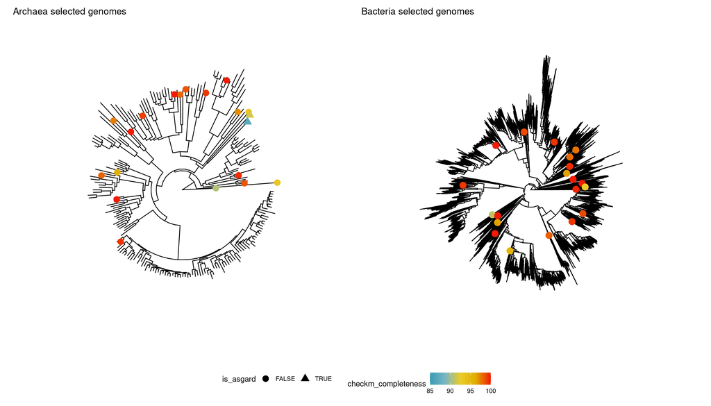

```r
ar_final_file <- paste0(ar53_file, ".filtered_trimmed_tree_X_", target_species)
ar_final <- read.tree(ar_final_file)

bac_final_file <- paste0(bac120_file, ".filtered_trimmed_tree_X_", target_species)
bac_final <- read.tree(bac_final_file)

ar_plot <- fortify(ar_intermediate) %>%
  left_join(ar_meta, by = c("label"="accession")) %>%
  mutate(is_selected=label %in% ar_final$tip.label, is_asgard=label %in% asgard_tips) %>%
  ggtree(layout = "circular") +
  ggtitle("Archaea selected genomes") +
  geom_tippoint(aes(color=checkm_completeness, shape=is_asgard), . %>% filter(is_selected), size=4) +
  xlim(c(0, max(vcv(ar_intermediate)))) +
  scale_color_gradientn(colours = wespal, limits=c(min_completeness-5, 100))

bac_plot <- fortify(bac_intermediate) %>%
  left_join(bac_meta, by = c("label"="accession")) %>%
  mutate(is_selected=label %in% bac_final$tip.label) %>%
  ggtree(layout = "circular") +
  ggtitle("Bacteria selected genomes") +
  geom_tippoint(aes(color=checkm_completeness), . %>% filter(is_selected), size=4) +
  xlim(c(0, max(vcv(bac_intermediate)))) +
  scale_color_gradientn(colours = wespal, limits=c(min_completeness-5, 100))

trees_plot <- ar_plot + bac_plot & theme(legend.position = "bottom")
trees_plot + plot_layout(guides = "collect")
```

```r
ar_final_table <- filter(ar_meta, accession %in% ar_final$tip.label) %>%
  left_join(up_genomes, by=c("ncbi_genbank_assembly_accession"="assembly")) %>%
  mutate(phylum=gsub(";.*", "", gsub(".*;p__", "", gtdb_taxonomy)), kingdom="Archaea") %>%
  select(Proteome_ID, ncbi_genbank_assembly_accession, Species_Name, phylum,
         protein_count, genome_size, checkm_completeness, checkm_contamination) %>%
  arrange(phylum)

bac_final_table <- filter(bac_meta, accession %in% bac_final$tip.label) %>%
  left_join(up_genomes, by=c("ncbi_genbank_assembly_accession"="assembly")) %>%
  mutate(phylum=gsub(";.*", "", gsub(".*;p__", "", gtdb_taxonomy)), kingdom="Bacteria") %>%
  select(Proteome_ID, ncbi_genbank_assembly_accession, Species_Name, phylum,
         protein_count, genome_size, checkm_completeness, checkm_contamination) %>%
  arrange(phylum)

rbind(ar_final_table, bac_final_table) %>%
  kbl(booktabs = TRUE, longtable = TRUE) %>%
  kable_styling(bootstrap_options = "striped",
              font_size = 9,
              latex_options = c("hold_position","repeat_header"),position = "left")
```

| Proteome_ID | ncbi_genbank_assembly_accession | Species_Name | phylum | protein_count | genome_size | checkm_completeness | checkm_contamination |
| --- | --- | --- | --- | --- | --- | --- | --- |
| UP000723406 | GCA_016933575.1 | Thorarchaeota archaeon (strain OWC) | Asgardarchaeota | 3330 | 3466336 | 86.92 | 4.42 |
| UP000321408 | GCA_008000775.1 | Candidatus Prometheoarchaeum syntrophicum | Asgardarchaeota | 3949 | 4427796 | 91.74 | 6.07 |
| UP000005233 | GCA_000251105.1 | Methanocella conradii (strain DSM 24694 / JCM 17849 / CGMCC 1.5162 / HZ254) | Halobacteriota | 2514 | 2378438 | 100.00 | 0.00 |
| UP000186940 | GCA_001766815.1 | Candidatus Syntrophoarchaeum caldarius | Halobacteriota | 1763 | 1666081 | 96.08 | 0.33 |
| UP000292580 | GCA_004297185.1 | Methanofollis fontis | Halobacteriota | 2301 | 2357249 | 98.20 | 0.65 |
| UP000252983 | GCA_003298465.1 | halophilic archaeon | Halobacteriota | 5681 | 5605381 | 99.36 | 3.48 |
| UP000009227 | GCA_000214415.1 | Methanotorris igneus (strain DSM 5666 / JCM 11834 / Kol 5) | Methanobacteriota | 1822 | 1854197 | 99.52 | 0.00 |
| UP000009079 | GCA_000022545.1 | Thermococcus sibiricus (strain DSM 12597 / MM 739) | Methanobacteriota_B | 2021 | 1845800 | 98.51 | 0.00 |
| UP000729398 | GCA_016932815.1 | Micrarchaeota archaeon | Micrarchaeota | 1224 | 1246214 | 93.15 | 0.00 |
| UP000001400 | GCA_000025665.1 | Aciduliprofundum boonei (strain DSM 19572 / T469) | Thermoplasmatota | 1558 | 1486778 | 100.00 | 0.00 |
| UP000001024 | GCA_000195915.1 | Thermoplasma acidophilum (strain ATCC 25905 / DSM 1728 / JCM 9062 / NBRC 15155 / AMRC-C165) | Thermoplasmatota | 1570 | 1564906 | 97.52 | 0.00 |
| UP000001037 | GCA_000223395.1 | Pyrolobus fumarii (strain DSM 11204 / 1A) | Thermoproteota | 2037 | 1843267 | 99.05 | 0.79 |
| UP000001015 | GCA_000011205.1 | Sulfurisphaera tokodaii (strain DSM 16993 / JCM 10545 / NBRC 100140 / 7) (Sulfolobus tokodaii) | Thermoproteota | 3005 | 2694756 | 100.00 | 0.00 |
| UP000245022 | GCA_003116855.1 | Desulfurococcaceae archaeon AG1 | Thermoproteota | 1932 | 1997414 | 98.10 | 0.00 |
| UP000001686 | GCA_000019605.1 | Korarchaeum cryptofilum (strain OPF8) | Thermoproteota | 1683 | 1590757 | 93.39 | 2.80 |
| UP000000641 | GCA_000015225.1 | Thermofilum pendens (strain DSM 2475 / Hrk 5) | Thermoproteota | 1931 | 1813393 | 98.53 | 0.74 |
| UP000008037 | GCA_000303155.1 | Nitrososphaera gargensis (strain Ga9.2) | Thermoproteota | 3768 | 2833868 | 100.00 | 2.91 |
| UP000006681 | GCA_000148385.1 | Vulcanisaeta distributa (strain DSM 14429 / JCM 11212 / NBRC 100878 / IC-017) | Thermoproteota | 2570 | 2374137 | 99.26 | 0.74 |
| UP000236627 | GCA_002898355.1 | archaeon HR01 | Thermoproteota | 1947 | 1761185 | 97.09 | 0.00 |
| UP000646946 | GCA_014189685.1 | Candidatus Naiadarchaeum limnaeum | Undinarchaeota | 1124 | 983883 | 90.65 | 2.80 |
| UP000236617 | GCA_002923315.1 | bacterium HR10 | Acidobacteriota | 2786 | 3131958 | 91.13 | 1.97 |
| UP000451738 | GCA_009377835.1 | Nitriliruptorales bacterium | Actinomycetota | 3576 | 3342050 | 98.77 | 4.70 |
| UP000265614 | GCA_003594885.1 | Vallicoccus soli | Actinomycetota | 3767 | 4045354 | 100.00 | 0.53 |
| UP000253314 | GCA_003318295.1 | Bacillus taeanensis | Bacillota | 4582 | 4611265 | 99.34 | 2.67 |
| UP000002156 | GCA_000019085.1 | Thermoanaerobacter pseudethanolicus (strain ATCC 33223 / 39E) (Clostridium thermohydrosulfuricum) | Bacillota_A | 2324 | 2362816 | 99.52 | 0.24 |
| UP000008457 | GCA_000213255.1 | Mahella australiensis (strain DSM 15567 / CIP 107919 / 50-1 BON) | Bacillota_A | 2970 | 3135972 | 97.98 | 1.48 |
| UP000235589 | GCA_002874775.1 | Monoglobus pectinilyticus | Bacillota_A | 2266 | 2759678 | 97.76 | 0.34 |
| UP000267250 | GCA_003991135.1 | Anoxybacter fermentans | Bacillota_F | 3182 | 3557532 | 96.58 | 2.54 |
| UP000480178 | GCA_010119975.1 | Rhodocytophaga rosea | Bacteroidota | 7647 | 8983451 | 99.29 | 1.82 |
| UP000001520 | GCA_000010985.1 | Deferribacter desulfuricans (strain DSM 14783 / JCM 11476 / NBRC 101012 / SSM1) | Deferribacterota | 2468 | 2542933 | 96.55 | 1.72 |
| UP000319449 | GCA_007830735.1 | Geobacter argillaceus | Desulfobacterota_F | 4014 | 4385310 | 100.00 | 0.00 |
| UP000007719 | GCA_000021645.1 | Dictyoglomus turgidum (strain DSM 6724 / Z-1310) | Dictyoglomota | 1818 | 1855560 | 100.00 | 0.00 |
| UP000317093 | GCA_007748055.1 | Planctomycetes bacterium Pan216 | Planctomycetota | 5783 | 7613473 | 100.00 | 3.49 |
| UP000252707 | GCA_003337735.1 | Thioalbus denitrificans | Pseudomonadota | 3827 | 4145766 | 99.28 | 4.11 |
| UP000002586 | GCA_000014865.1 | Magnetococcus marinus (strain ATCC BAA-1437 / JCM 17883 / MC-1) | Pseudomonadota | 3924 | 4719581 | 98.32 | 0.84 |
| UP000469391 | GCA_009649675.1 | Alphaproteobacteria bacterium HT1-32 | Pseudomonadota | 4086 | 4423878 | 100.00 | 0.50 |
| UP000284605 | GCA_003590945.1 | Oleomonas cavernae | Pseudomonadota | 5701 | 5643452 | 95.43 | 1.16 |
| UP000077574 | GCA_001644975.1 | Piscirickettsiaceae bacterium NZ-RLO1 | Pseudomonadota | 3159 | 3052667 | 98.81 | 0.57 |
| UP000253869 | GCA_003346715.1 | Oceanispirochaeta sp. M1 | Spirochaetota | 5191 | 5884319 | 99.73 | 3.73 |
| UP000035268 | GCA_001017655.1 | Kiritimatiella glycovorans | Verrucomicrobiota | 2429 | 2949723 | 92.74 | 3.21 |

# Run LUCA analysis

We will add then these 40 proteomes to the 18 Eukaryotes of the *H. sapiens Opisthokonta* dataset and create the file *data/input_tables/LUCA.csv* that will be then used in the pipeline.

```r
read_delim(euka, delim = "\t", col_names = colnames(up_genomes_raw), show_col_types = FALSE) %>%
  rbind(up_genomes_raw[up_genomes_raw$Proteome_ID %in% ar_final_table$Proteome_ID, ]) %>%
  rbind(up_genomes_raw[up_genomes_raw$Proteome_ID %in% bac_final_table$Proteome_ID, ]) %>%
  write_delim("data/input_tables/LUCA.csv", delim = "\t", col_names = FALSE)
```

First you need to download the structures, do this in local:

```bash
snakemake --configfile data/configs/LUCA.yaml -p -j2 --until download_pdbs -s workflow/download_data.smk
snakemake --configfile data/configs/LUCA.yaml -p -j2 --until download_uniprot_ids -s workflow/download_data.smk
```

Then run on MN the remaining steps to decompress:

```bash
snakemake --configfile data/configs/LUCA.yaml -p -j24 -s workflow/download_data.smk
```

Finally, run the pipeline until the homology call:

```bash
snakemake --configfile data/configs/LUCA.yaml -p -j24 --until plot_evalues
```